# Lab 7: Implementing Cross Validation (CV)

**Getting Started**

1. Download the `.qmd` file from Moodle and any needed `.xlsx` or `.csv` data files. Save these in the *same folder/directory*.
2. Open the Quarto file in RStudio: `File > Open File... >`. If you’re working on the MHC RStudio server, you need to upload the files first: go to the `Files` panel, then click `Upload`. Upload the `.qmd` file and any data files. You will need to upload each file one at a time.
3. Update the author and date in the YAML header of this file.
4. Click the `Render` button. If successful, you should have a new window pop up with a nice looking HTML document.

**Ask for help** if you encounter issues on any of the steps above. Once you’ve successfully made it through these steps, you can continue.

**Goals**

- Build a linear regression model of the height (in feet) of a black cherry tree given its diameter in inches (X)
- Use $k$-fold cross validation to evaluate strength of this predictive (linear regression) model

## Context

- **Broader subject area: supervised learning**  
  We want to build a model for some output RV $Y$ given various predictor RVs $X_1, \ldots, X_p$.
- **Task: regression**  
  $Y$ is quantitative (takes numerical values)
- **Algorithm: linear regression model**  
  We’ll assume that the relationship between $Y$ and $X$ can be represented by

$$\mathbb{E}(Y \mid X_1, \ldots, X_p) = \beta_0 + \beta_1 X_1 + \beta_2 X_2 + \cdots + \beta_p X_p$$

## Review: $k$-Fold Cross Validation

We can use **k-fold cross-validation** to estimate the typical error in our model predictions for *new* data:

- Divide the data into $k$ folds (or groups) of approximately equal size.
- Repeat the following procedures for each fold $j = 1,2,...,k$:
  - Remove fold $j$ from the data set.
  - Fit a model using the data in the other $k-1$ folds (training).
  - Use this model to predict the responses for the $n_j$ cases in fold $j$: $\hat{y}_1, ..., \hat{y}_{n_j}$.
  - Calculate the MAE for fold $j$ (testing): $\text{MAE}_j = \frac{1}{n_j}\sum_{i=1}^{n_j} |y_i - \hat{y}_i|$.
- Combine this information into one measure of model quality:
  $$\text{CV}_{(k)} = \frac{1}{k} \sum_{j=1}^k \text{MAE}_j$$

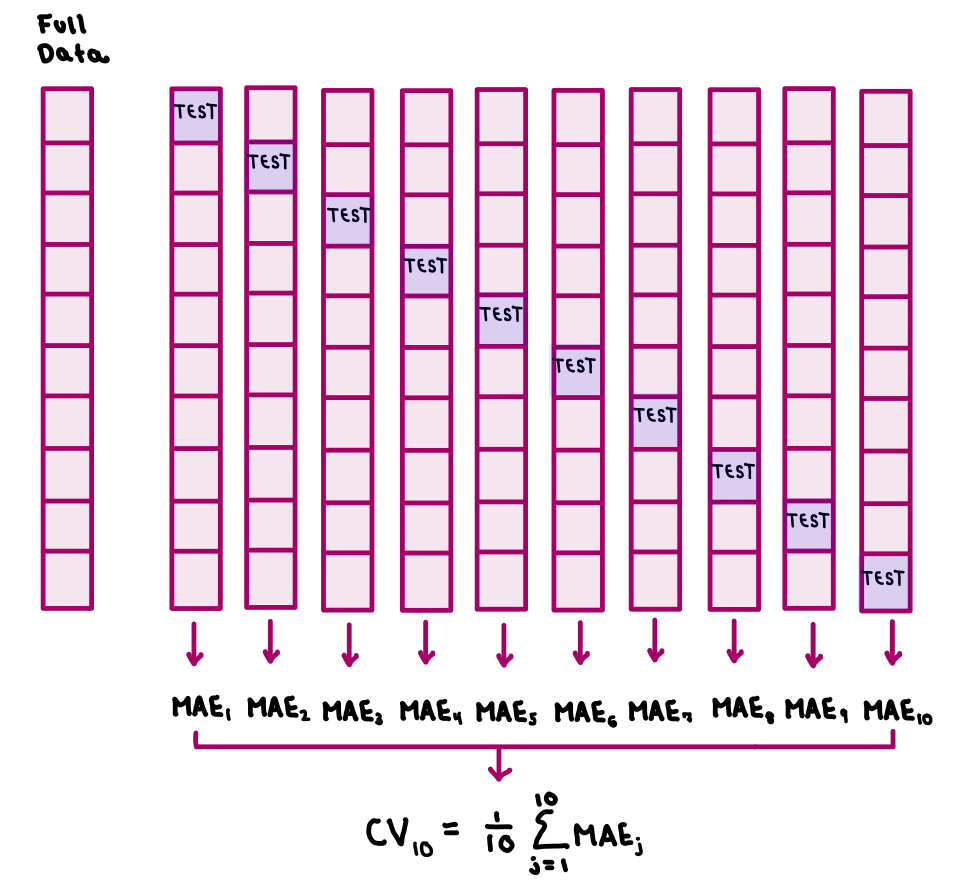

**Vocabulary**

> A **tuning parameter** is *parameter* or quantity upon which an algorithm depends whose value is *selected* or *tuned* to “optimize” the algorithm.

For $k$-fold CV, the tuning parameter is $k$, where $2 \le k \le n$, where $n$ is the number of observations.

*Heuristic*: $k$ is usually picked to be something in the middle.

## Set Up

### Load Libraries

```r
library(tidyverse)
library(tidymodels)
library(readxl)
# Load data
data(trees)
```

### Rename Columns (Variables)

- Rename `Girth` to `diameter`
- Rename `Height` to `height`

```r
# Rename columns
trees = trees %>%
  rename(diameter = Girth, height = Height) %>%
  # Only have height and diameter be the columns
  select(height, diameter)
```

### Visualization (Scatter Plot)

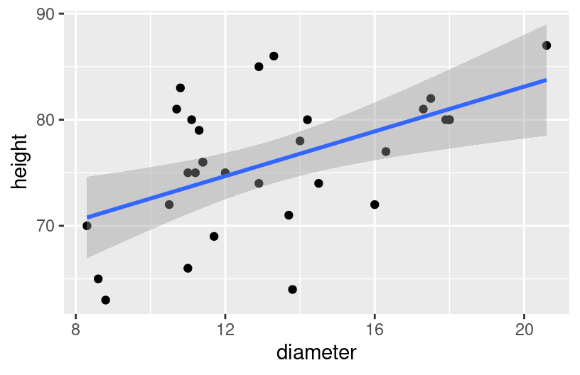

```r
# Create a scatter plot
ggplot(trees, aes(x = diameter, y = height)) +
  geom_point() +
  geom_smooth(method = "lm")
```

**Observations**

- Height appears to be (weakly) positively correlated with diameter

```r
# Step 1: Model specification
lm_spec <- linear_reg() %>%
  # Output Y is quantitative
  set_mode("regression") %>%
  # Want regression to be lienar
  set_engine("lm")
```

```r
# Step 2: Model estimation
tree_model <- lm_spec %>%
  fit(height ~ diameter, data = trees)
```

## 10-Fold Cross Validation

### Procedure

- Randomly split the data into 10 folds
- Built model 10 times, leaving 1 test fold out each time
- Evaluate each model on the test fold (using MAE/MSE and R-squared as error metrics)

```r
# For reproducibility
set.seed(242)

tree_model_cv = lm_spec %>%
# fit_resamples() function is for fitting on folds
fit_resamples(
  # Specify the relationship
  height ~ diameter,
  # vfold_cv makes CV folds randomly from
  # trees data set
  resamples = vfold_cv(trees, v = 10),
  # Specify the error metrics
  # (MAE, square root MSE, R^2)
  metrics = metric_set(mae, rmse, rsq)
  )
```

```r
tree_model_cv %>% collect_metrics()
```

```
# A tibble: 3 × 6
  .metric .estimator  mean     n std_err .config
  <chr>   <chr>      <dbl> <int>   <dbl> <chr>
1 mae     standard   4.38     10   0.639 Preprocessor1_Model1
2 rmse    standard   5.17     10   0.733 Preprocessor1_Model1
3 rsq     standard   0.341    10   0.121 Preprocessor1_Model1
```

### Summarizing

```r
# Get fold-by-fold results
# Get info for each test fold
tree_model_cv %>% unnest(.metrics) %>%
filter(.metric == "mae")
```

```
# A tibble: 10 × 7
   splits         id     .metric .estimator .estimate .config           .notes
   <list>         <chr>  <chr>   <chr>          <dbl> <chr>             <list>
 1 <split [27/4]> Fold01 mae     standard        4.23 Preprocessor1_Mo… <tibble>
 2 <split [28/3]> Fold02 mae     standard        5.67 Preprocessor1_Mo… <tibble>
 3 <split [28/3]> Fold03 mae     standard        7.92 Preprocessor1_Mo… <tibble>
 4 <split [28/3]> Fold04 mae     standard        3.59 Preprocessor1_Mo… <tibble>
 5 <split [28/3]> Fold05 mae     standard        6.11 Preprocessor1_Mo… <tibble>
 6 <split [28/3]> Fold06 mae     standard        1.42 Preprocessor1_Mo… <tibble>
 7 <split [28/3]> Fold07 mae     standard        1.99 Preprocessor1_Mo… <tibble>
 8 <split [28/3]> Fold08 mae     standard        2.76 Preprocessor1_Mo… <tibble>
 9 <split [28/3]> Fold09 mae     standard        5.70 Preprocessor1_Mo… <tibble>
10 <split [28/3]> Fold10 mae     standard        4.37 Preprocessor1_Mo… <tibble>
```

**Observations**

# Exercises

```r
# Load packages and data
health_data = read_xlsx("healthdata.xlsx")
```

```
Error: `path` does not exist: 'healthdata.xlsx'
```

## EXERCISE 1: In-Sample Metrics

Use the `health_data` data to build two separate models of `height`:

```r
# STEP 2: model estimation
model_1 <- lm_spec %>%
  fit(height ~ hip + weight + thigh + knee + ankle, data = health_data)
```

```
Error in is_list(data): object 'health_data' not found
```

```r
model_2 <- lm_spec %>%
  fit(height ~ chest * age * weight + abdomen + hip + thigh + knee + ankle + biceps + forearm + wrist, data = health_data)
```

```
Error in is_list(data): object 'health_data' not found
```

Calculate the **in-sample** R-squared for both models:

```r
# IN-SAMPLE R^2 for model_1 = ???
model_1 %>% glance()
```

```
Error in glance(.): object 'model_1' not found
```

```r
# IN-SAMPLE R^2 for model_2 = ???
model_2 %>% glance()
```

```
Error in glance(.): object 'model_2' not found
```

Calculate the **in-sample** MAE for both models:

```r
# IN-SAMPLE MAE for model_1 = ???
model_1 %>%
  augment(new_data = health_data) %>%
  mae(truth = height, estimate = .pred)
```

```
Error in augment(., new_data = health_data): object 'model_1' not found
```

```r
# IN-SAMPLE MAE for model_2 = ???
model_2 %>%
  augment(new_data = health_data) %>%
  mae(truth = height, estimate = .pred)
```

```
Error in augment(., new_data = health_data): object 'model_2' not found
```

## EXERCISE 2: In-Sample Model Comparison

Which model seems “better” by the in-sample metrics you calculated above? Any concerns about either of these models?

## EXERCISE 3: 10-Fold CV

Complete the code to run 10-fold cross-validation for our two models.

`model_1`: `height ~ hip + weight + thigh + knee + ankle`  
`model_2`: `height ~ chest * age * weight + abdomen + hip + thigh + knee + ankle + biceps + forearm + wrist`

```r
# 10-fold cross-validation for model_1
set.seed(244)
model_1_cv <- lm_spec %>%
  fit_resamples(
    height ~ height ~ hip + weight + thigh + knee + ankle,
    resamples = vfold_cv(health_data, v = 10),
    metrics = metric_set(mae, rsq)
  )
```

```
Error in nrow(data): object 'health_data' not found
```

```r
# 10-fold cross-validation for model_2
set.seed(253)
model_2_cv <- lm_spec %>%
  fit_resamples(
    height ~ chest * age * weight + abdomen + hip + thigh + knee + ankle + biceps + forearm + wrist,
    resamples = vfold_cv(health_data, v = 10),
    metrics = metric_set(mae, rsq)
  )
```

```
Error in nrow(data): object 'health_data' not found
```

## EXERCISE 4: Calculating the CV MAE

1. Use `collect_metrics()` to obtain the cross-validated MAE and $R^2$ for both models.

```r
model_1_cv %>%
  collect_metrics()
```

```
Error in collect_metrics(.): object 'model_1_cv' not found
```

```r
model_2_cv %>%
  collect_metrics()
```

```
Error in collect_metrics(.): object 'model_2_cv' not found
```

2. Interpret the cross-validated MAE *and* $R^2$ for `model_1`.

## EXERCISE 5: Fold-By-Fold Results

The command `collect_metrics()` gave the final CV MAE, or the average MAE across all 10 test folds. The command `unnest(.metrics)` provides the MAE from *each* test fold.

1. Obtain the fold-by-fold results for the `model_1` cross-validation procedure using `unnest(.metrics)`.

```r
model_1_cv %>%
  unnest(.metrics) %>%
  filter(.metric == "mae")
```

```
Error in unnest(., .metrics): object 'model_1_cv' not found
```

2. Which fold had the worst average prediction error and what was it?

```r
# Code here
model_1_cv %>%
  unnest(.metrics) %>%
  filter(.metric == "mae") %>%
  summarize(mean(.estimate))
```

```
Error in unnest(., .metrics): object 'model_1_cv' not found
```

## EXERCISE 6: Comparing Models

Fill in the table below to summarize the in-sample and 10-fold CV MAE for both models.

[output not shown]

1. Based on the in-sample MAE alone, which model appears better?

## EXERCISE 7: LOOCV

1. Reconsider `model_1`. Instead of estimating its prediction accuracy using the 10-fold CV MAE, use the LOOCV MAE. THINK: How many people are in our `health_data` sample?

```r
# CODE HERE

model_1_loocv <- lm_spec %>%
  fit_resamples(
    height ~ hip + weight + thigh + knee + ankle,
    resamples = vfold_cv(health_data, v = nrow(health_data)),
    metrics = metric_set(mae)
  )
```

```
Error in nrow(data): object 'health_data' not found
```

```r
model_1_loocv %>% collect_metrics()
```

```
Error in collect_metrics(.): object 'model_1_loocv' not found
```